# Analyzing Individual BGG Users

Phil Henrickson

2021-12-06

Load previously queried training and test data from the local layer.

Set function for displaying probabilities

Fit models and analyze collection for **mrbananagrabber**.

## Games in Collection

How many games has the user owned/played in the training set (games prior to 2020)?

```
## # A tibble: 1 × 3
##   username        games_owned games_played
##   <chr>                 <dbl>        <dbl>
## 1 mrbananagrabber          87          109
```

## Coefficients for mrbananagrabber

Examine coefficients from the trained model.

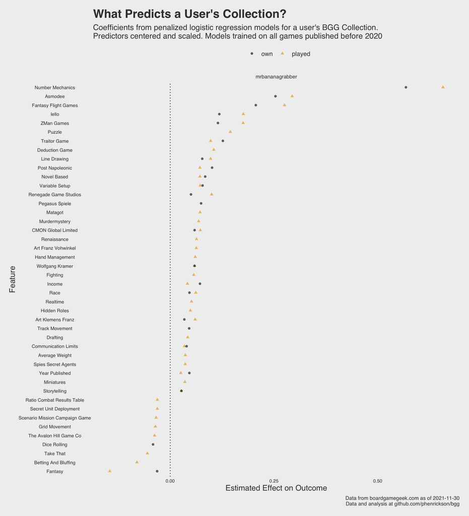

## Visualizing Predictors for mrbananagrabber’s Collection

Examine density of most important features for predicting whether user owns a game.

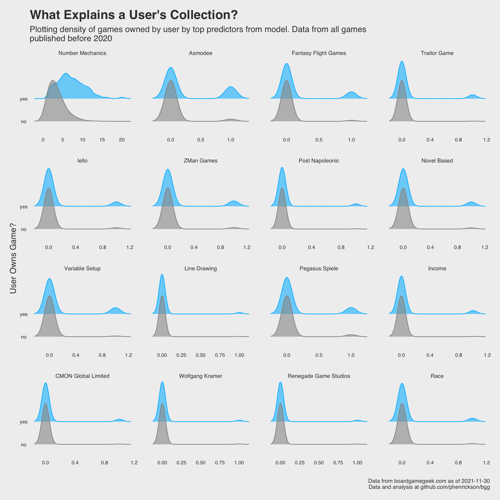

## Assessment

Examine separation plot for training set (cross validated predictions).

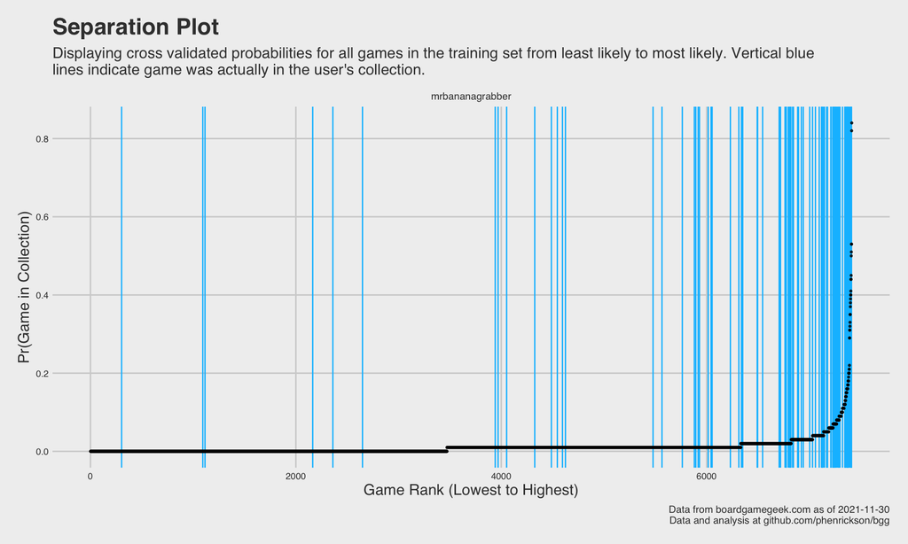

Formally assess how well the model did in resampling.

| outcome_type | .metric | .estimator | .estimate |
| --- | --- | --- | --- |
| own | roc_auc | binary | 0.870 |
| played | roc_auc | binary | 0.874 |

## Predicted Games in Collection from Training

Examine top games from resampling.

Top Overall Games for User from Resampling

| username | yearpublished | game_id | name | pred_played | pred_own | actual_played | actual_own |
| --- | --- | --- | --- | --- | --- | --- | --- |
| mrbananagrabber | 2018 | 205896 | Rising Sun | 0.84 | 0.84 | 0 | 0 |
| mrbananagrabber | 2008 | 37111 | Battlestar Galactica: The Board Game | 0.95 | 0.82 | 1 | 0 |
| mrbananagrabber | 2017 | 174430 | Gloomhaven | 0.75 | 0.53 | 1 | 1 |
| mrbananagrabber | 2016 | 205716 | New Angeles | 0.77 | 0.53 | 0 | 0 |
| mrbananagrabber | 2014 | 156129 | Deception: Murder in Hong Kong | 0.81 | 0.51 | 1 | 1 |
| mrbananagrabber | 2019 | 266507 | Clank!: Legacy – Acquisitions Incorporated | 0.39 | 0.50 | 0 | 0 |
| mrbananagrabber | 2016 | 205059 | Mansions of Madness: Second Edition | 0.83 | 0.45 | 1 | 1 |
| mrbananagrabber | 1997 | 42 | Tigris & Euphrates | 0.43 | 0.44 | 0 | 0 |
| mrbananagrabber | 2017 | 233078 | Twilight Imperium: Fourth Edition | 0.74 | 0.44 | 1 | 1 |
| mrbananagrabber | 2015 | 175878 | 504 | 0.36 | 0.41 | 0 | 0 |
| mrbananagrabber | 2010 | 73171 | Earth Reborn | 0.55 | 0.40 | 0 | 0 |
| mrbananagrabber | 2013 | 127024 | Room 25 | 0.66 | 0.40 | 0 | 0 |
| mrbananagrabber | 2019 | 270971 | Era: Medieval Age | 0.21 | 0.39 | 0 | 0 |
| mrbananagrabber | 2004 | 9220 | Saboteur | 0.35 | 0.38 | 0 | 0 |
| mrbananagrabber | 2018 | 209324 | The World of SMOG: Rise of Moloch | 0.39 | 0.37 | 0 | 0 |
| mrbananagrabber | 1995 | 13 | Catan | 0.32 | 0.35 | 1 | 0 |
| mrbananagrabber | 2012 | 121921 | Robinson Crusoe: Adventures on the Cursed Island | 0.37 | 0.35 | 0 | 0 |
| mrbananagrabber | 2012 | 105551 | Archipelago | 0.34 | 0.33 | 1 | 1 |
| mrbananagrabber | 2017 | 215311 | Downforce | 0.08 | 0.32 | 0 | 0 |
| mrbananagrabber | 2017 | 220308 | Gaia Project | 0.18 | 0.31 | 0 | 0 |
| mrbananagrabber | 2004 | 10547 | Betrayal at House on the Hill | 0.39 | 0.31 | 0 | 0 |
| mrbananagrabber | 2018 | 244711 | Newton | 0.79 | 0.29 | 0 | 0 |
| mrbananagrabber | 2005 | 15062 | Shadows over Camelot | 0.13 | 0.29 | 0 | 0 |
| mrbananagrabber | 2016 | 168681 | Beyond Baker Street | 0.48 | 0.22 | 0 | 0 |
| mrbananagrabber | 2004 | 9609 | War of the Ring | 0.43 | 0.21 | 0 | 0 |
| mrbananagrabber | 2012 | 123096 | Space Cadets | 0.40 | 0.21 | 1 | 0 |
| mrbananagrabber | 2019 | 276025 | Maracaibo | 0.46 | 0.20 | 1 | 1 |
| mrbananagrabber | 2011 | 59959 | Letters from Whitechapel | 0.49 | 0.20 | 1 | 0 |
| mrbananagrabber | 1976 | 3083 | Submarine | 0.19 | 0.20 | 0 | 0 |
| mrbananagrabber | 2017 | 188920 | This War of Mine: The Board Game | 0.27 | 0.20 | 0 | 0 |

[output cut: 70 more lines]

### Most and Least Likely Games

What game does the model think mrbananagrabber is **most likely to own** that is **not** in their collection?

| username | yearpublished | game_id | name | pred_own |
| --- | --- | --- | --- | --- |
| mrbananagrabber | 2018 | 205896 | Rising Sun | 0.84 |

What game does the model think mrbananagrabber is **least likely to own** that **is** in their collection?

| username | yearpublished | game_id | name | pred_own |
| --- | --- | --- | --- | --- |
| mrbananagrabber | 2018 | 247367 | Air, Land & Sea | 0 |

### Top Games by Year

Top 25 games most likely to be owned by the user in each year, highlighting in blue the games that the user has owned/played.

| rank | 2012 | 2013 | 2014 | 2015 | 2016 | 2017 | 2018 | 2019 |
| --- | --- | --- | --- | --- | --- | --- | --- | --- |
| 1 | Robinson Crusoe: Adventures on the Cursed Island | Room 25 | Deception: Murder in Hong Kong | 504 | New Angeles | Gloomhaven | Rising Sun | Clank!: Legacy – Acquisitions Incorporated |
| 2 | Archipelago | Impulse | Sheriff of Nottingham | Runebound (Third Edition) | Mansions of Madness: Second Edition | Twilight Imperium: Fourth Edition | The World of SMOG: Rise of Moloch | Era: Medieval Age |
| 3 | Space Cadets | Patchistory | Ultimate Werewolf | Blood Rage | Beyond Baker Street | Downforce | Newton | Maracaibo |
| 4 | Wiz-War (Eighth Edition) | Prosperity | Dead of Winter: A Crossroads Game | Mysterium | Captain Sonar | Gaia Project | Cosmic Encounter: 42nd Anniversary Edition | The Lord of the Rings: Journeys in Middle-Earth |
| 5 | Descent: Journeys in the Dark (Second Edition) | Lewis & Clark: The Expedition | Patchwork | Grand Austria Hotel | Timebomb | This War of Mine: The Board Game | Treasure Island | Last Bastion |
| 6 | Keyflower | Eldritch Horror | Sons of Anarchy: Men of Mayhem | Risk: Europe | Terraforming Mars | Breaking Bad: The Board Game | Arkham Horror (Third Edition) | The King's Dilemma |
| 7 | Terra Mystica | Ladies & Gentlemen | Akrotiri | The Voyages of Marco Polo | When I Dream | Fallout | Everdell | Sierra West |
| 8 | Pax Porfiriana | Tash-Kalar: Arena of Legends | Fields of Arle | One Night Ultimate Vampire | Inis | Spirit Island | Nemesis | Tainted Grail: The Fall of Avalon |
| 9 | Zombicide | Ultimate Werewolf: Inquisition | Five Tribes | Mombasa | Black Orchestra | Summit: The Board Game | Gingerbread House | Tapestry |
| 10 | The Resistance: Avalon | The Doom That Came to Atlantic City | Spyfall | Salem 1692 | Game of Thrones: The Iron Throne | Pendragon: The Fall of Roman Britain | Betrayal Legacy | The Magnificent |
| 11 | Legends of Andor | BANG! The Dice Game | HINT | One Night Ultimate Werewolf: Daybreak | Citadels | Heaven & Ale | Brass: Birmingham | Barrage |
| 12 | Il Vecchio | Bruxelles 1893 | La Granja | Drakon (Fourth Edition) | Pandemic: Iberia | Whitehall Mystery | Teotihuacan: City of Gods | Pax Pamir: Second Edition |
| 13 | Targi | The Witches: A Discworld Game | The Witcher Adventure Game | Forbidden Stars | Pandemic: Reign of Cthulhu | Photosynthesis | Who Goes There? | Star Wars: Outer Rim |
| 14 | Merchant of Venus (Second Edition) | Warhammer: Diskwars | Camel Up | The Bloody Inn | Agricola (Revised Edition) | Pandemic Legacy: Season 2 | Pandemic: Fall of Rome | Hellenica: Story of Greece |
| 15 | Smash Up | Legacy: The Testament of Duke de Crecy | Three Kingdoms Redux | The Pursuit of Happiness | Bloodborne: The Card Game | Smash Up: What Were We Thinking? | A Song of Ice & Fire: Tabletop Miniatures Game – Stark vs Lannister Starter Set | Zombicide: Invader |
| 16 | Love Letter | Mascarade | Deus | Steampunk Rally | Dead of Winter: The Long Night | Betrayal at Baldur's Gate | Heroes of Terrinoth | The Isle of Cats |
| 17 | Winter Tales | Spyrium | Arcadia Quest | Watson & Holmes | Codenames: Pictures | One Night Ultimate Alien | Duelosaur Island | Tiny Towns |
| 18 | One Night Werewolf | Forbidden Desert | DungeonQuest Revised Edition | Mission: Red Planet (Second Edition) | A Feast for Odin | LYNGK | Root | Century: A New World |
| 19 | Rumble in the Dungeon | BattleLore: Second Edition | Istanbul | Burgle Bros. | Tales & Games: Aladdin & the Magic Lamp | Dinosaur Island | Gen7: A Crossroads Game | PARKS |
| 20 | Sewer Pirats | City of Remnants | Star Wars: Imperial Assault | Trickerion: Legends of Illusion | Exceed Fighting System | Sherlock Holmes Consulting Detective: Carlton House & Queen's Park | Human Punishment: Social Deduction 2.0 | Yukon Airways |
| 21 | Divided Republic | Theseus: The Dark Orbit | Gaïa | The King Is Dead | Aeon's End | Massive Darkness | Zombicide: Green Horde | Call to Adventure |
| 22 | War of the Ring: Second Edition | Glass Road | Witness | Through the Ages: A New Story of Civilization | Star Wars: Rebellion | Harvest Dice | Renegade | Black Angel |
| 23 | Clash of Cultures | Coal Baron | Ultimate Werewolf: Deluxe Edition | A Study in Emerald (Second Edition) | The Oracle of Delphi | The Godfather: Corleone's Empire | Century: Eastern Wonders | Pandemic: Rapid Response |
| 24 | Rex: Final Days of an Empire | LEADERS: The Combined Strategy Game | Colt Express | The Grizzled | Covert | Runewars Miniatures Game | Sonar Family | GROWL |
| 25 | Game of Thrones: The Card Game | Gear & Piston | King of New York | Exploding Kittens | Dream Home | Fog of Love | Street Masters | Cthulhu: Death May Die |

### Interactive Table

Interactive table for predictions from resampling.

|  | username | yearpublished | rank | game_id | name | pred_played | pred_own | actual_played | actual_own |
| --- | --- | --- | --- | --- | --- | --- | --- | --- | --- |
| 1 | mrbananagrabber | 1900 | 909 | 15878 | Rummy | 0.01 | 0.02 | 0 | 0 |
| 2 | mrbananagrabber | 1900 | 940 | 2386 | Chinese Checkers | 0.02 | 0.02 | 0 | 0 |
| 3 | mrbananagrabber | 1900 | 963 | 2785 | Game of Goose | 0.02 | 0.02 | 0 | 0 |
| 4 | mrbananagrabber | 1900 | 1151 | 171 | Chess | 0.01 | 0.01 | 0 | 0 |
| 5 | mrbananagrabber | 1900 | 1268 | 1602 | The Royal Game of Ur | 0.02 | 0.01 | 0 | 0 |
| 6 | mrbananagrabber | 1900 | 1269 | 2083 | Checkers | 0.01 | 0.01 | 0 | 0 |
| 7 | mrbananagrabber | 1900 | 1271 | 2397 | Backgammon | 0.01 | 0.01 | 0 | 0 |
| 8 | mrbananagrabber | 1900 | 1406 | 10213 | Fox and Geese | 0 | 0.01 | 0 | 0 |
| 9 | mrbananagrabber | 1900 | 2028 | 2173 | 4 Player Chess | 0.01 | 0.01 | 0 | 0 |
| 10 | mrbananagrabber | 1900 | 2227 | 21389 | Happy Families | 0.01 | 0.01 | 0 | 0 |

[output cut: 7403 more lines]

## Predicted Games in Collection 2020 and On

Examine the top games for the test set.

Top Predicted Games for User, 2020 and On

| username | yearpublished | game_id | name | rank | own | played |
| --- | --- | --- | --- | --- | --- | --- |
| mrbananagrabber | 2020 | 291457 | Gloomhaven: Jaws of the Lion | 1 | 0.39 | 0.55 |
| mrbananagrabber | 2020 | 292333 | Cowboys II: Cowboys & Indians Edition | 2 | 0.26 | 0.52 |
| mrbananagrabber | 2020 | 256317 | Guild Master | 3 | 0.24 | 0.30 |
| mrbananagrabber | 2020 | 300322 | Hallertau | 4 | 0.24 | 0.30 |
| mrbananagrabber | 2020 | 184267 | On Mars | 5 | 0.24 | 0.47 |
| mrbananagrabber | 2020 | 246900 | Eclipse: Second Dawn for the Galaxy | 6 | 0.21 | 0.26 |
| mrbananagrabber | 2020 | 308765 | Praga Caput Regni | 7 | 0.15 | 0.20 |
| mrbananagrabber | 2020 | 298572 | Cosmic Encounter Duel | 8 | 0.11 | 0.22 |
| mrbananagrabber | 2020 | 316554 | Dune: Imperium | 9 | 0.10 | 0.12 |
| mrbananagrabber | 2020 | 306735 | Under Falling Skies | 10 | 0.10 | 0.16 |
| mrbananagrabber | 2020 | 308652 | Age of Dogfights: WW1 | 11 | 0.10 | 0.12 |
| mrbananagrabber | 2020 | 304434 | Victim: The Cursed Forest | 12 | 0.09 | 0.09 |
| mrbananagrabber | 2020 | 306481 | Tawantinsuyu: The Inca Empire | 13 | 0.09 | 0.16 |
| mrbananagrabber | 2020 | 297030 | Tekhenu: Obelisk of the Sun | 14 | 0.09 | 0.12 |
| mrbananagrabber | 2020 | 295905 | Cosmic Frog | 15 | 0.08 | 0.11 |
| mrbananagrabber | 2020 | 302809 | Betrayal at Mystery Mansion | 16 | 0.08 | 0.08 |
| mrbananagrabber | 2020 | 299179 | Chancellorsville 1863 | 17 | 0.08 | 0.08 |
| mrbananagrabber | 2020 | 294788 | Conqueror: Final Conquest | 18 | 0.07 | 0.04 |
| mrbananagrabber | 2020 | 314040 | Pandemic Legacy: Season 0 | 19 | 0.07 | 0.21 |
| mrbananagrabber | 2020 | 313817 | Hello Neighbor: The Secret Neighbor Party Game | 20 | 0.06 | 0.10 |
| mrbananagrabber | 2020 | 245224 | La Belle Époque | 21 | 0.06 | 0.07 |
| mrbananagrabber | 2020 | 256940 | Krosmaster: Blast | 22 | 0.06 | 0.09 |
| mrbananagrabber | 2020 | 301767 | Mysterium Park | 23 | 0.05 | 0.13 |
| mrbananagrabber | 2020 | 303057 | Pan Am | 24 | 0.05 | 0.05 |
| mrbananagrabber | 2020 | 302723 | Forgotten Waters | 25 | 0.05 | 0.04 |
| mrbananagrabber | 2020 | 306040 | Merv: The Heart of the Silk Road | 26 | 0.05 | 0.06 |
| mrbananagrabber | 2020 | 310442 | Feierabend | 27 | 0.05 | 0.06 |
| mrbananagrabber | 2020 | 320819 | Dinner In Paris | 28 | 0.05 | 0.08 |
| mrbananagrabber | 2020 | 298352 | The Shining | 29 | 0.05 | 0.05 |
| mrbananagrabber | 2021 | 340466 | Unfathomable | 1 | 0.50 | 0.73 |

[output cut: 55 more lines]

Interactive table for 2020 and On

|  | username | yearpublished | game_id | name | rank | own | played |
| --- | --- | --- | --- | --- | --- | --- | --- |
| 1 | mrbananagrabber | 2022 | 331106 | The Witcher: Old World | 1 | 0.54 | 0.81 |
| 2 | mrbananagrabber | 2022 | 317511 | Tindaya | 2 | 0.52 | 0.48 |
| 3 | mrbananagrabber | 2021 | 340466 | Unfathomable | 3 | 0.5 | 0.73 |
| 4 | mrbananagrabber | 2020 | 291457 | Gloomhaven: Jaws of the Lion | 4 | 0.39 | 0.55 |
| 5 | mrbananagrabber | 2021 | 343905 | Boonlake | 5 | 0.36 | 0.38 |
| 6 | mrbananagrabber | 2021 | 285967 | Ankh: Gods of Egypt | 6 | 0.29 | 0.49 |
| 7 | mrbananagrabber | 2021 | 310873 | Carnegie | 7 | 0.28 | 0.27 |
| 8 | mrbananagrabber | 2020 | 292333 | Cowboys II: Cowboys &amp; Indians Edition | 8 | 0.26 | 0.52 |
| 9 | mrbananagrabber | 2021 | 291847 | Mantis Falls | 9 | 0.25 | 0.47 |
| 10 | mrbananagrabber | 2020 | 256317 | Guild Master | 10 | 0.24 | 0.3 |

[output cut: 1566 more lines]